# **1. Warm Up**

We’ll try to explore goaltenders and consider who was the best goaltender of the 2017-2018 season.

Question 1

```python
df = get_player_stats(2018, 'goalies')
df.sort_values(by="SV%" , ascending=False)[0:5]
```

```
Retrieving data from 'https://www.hockey-reference.com/leagues/NHL_2018_goalies.html'...
```

|  | Rk | Player | Age | Tm | GP | GS | W | L | T/O | GA | SA | SV | SV% | GAA | SO | GPS | MIN | QS | QS% | RBS | GA%- | GSAA | G | A | PTS | PIM |
| --- | --- | --- | --- | --- | --- | --- | --- | --- | --- | --- | --- | --- | --- | --- | --- | --- | --- | --- | --- | --- | --- | --- | --- | --- | --- | --- |
| 27 | 29 | Scott Foster | 36 | CHI | 1 | 0 | 0 | 0 | 0 | 0 | 7 | 7 | 1.000 | 0.00 | 0 | 0.1 | 14 | 0 | NaN | 0 | NaN | NaN | 0 | 0 | 0 | 0 |
| 88 | 95 | Adam Wilcox | 25 | BUF | 1 | 0 | 0 | 1 | 0 | 0 | 14 | 14 | 1.000 | 0.00 | 0 | 0.2 | 39 | 0 | NaN | 0 | NaN | NaN | 0 | 0 | 0 | 0 |
| 51 | 55 | Marek Langhamer | 23 | ARI | 1 | 0 | 0 | 0 | 0 | 0 | 10 | 10 | 1.000 | 0.00 | 0 | 0.2 | 29 | 0 | NaN | 0 | NaN | NaN | 0 | 0 | 0 | 0 |
| 16 | 17 | Oscar Dansk | 23 | VEG | 4 | 3 | 3 | 0 | 0 | 5 | 93 | 88 | .946 | 1.78 | 1 | 0.9 | 169 | 3 | 1.000 | 0 | NaN | NaN | 0 | 0 | 0 | 0 |
| 3 | 4 | Kenneth Appleby | 22 | NJD | 3 | 1 | 0 | 1 | 0 | 3 | 55 | 52 | .945 | 1.45 | 0 | 0.5 | 124 | 0 | .000 | 0 | NaN | NaN | 0 | 0 | 0 | 0 |

If the ranking was only about goalies' save percentage (SV%), because this figure represents the ratio of their shots saved over the total number of shots they faced. Then SV% does not represent the true level of the goalie when the number of shots he faces is low, so most of the top are goalie who face fewer shots.  
To solve this problem, I set a minimum number of shots faced of 100, and only when a goalie has faced more than 100 shots this season does his SV % become less random.

Question 2

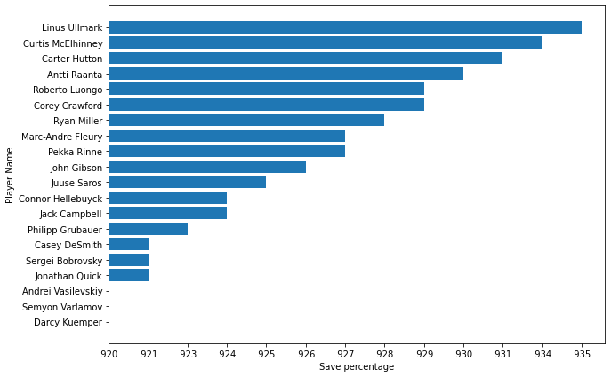

```python
df = df[df['SA'].astype(int) > 100]
df_sort = df.sort_values(by=['SV%'], ascending=False).head(20)
df_plot = df_sort.sort_values(by=['SV%'])
x = df_plot['Player'].head(20)
y = df_plot['SV%'].head(20)
fig = plt.figure(figsize =(10, 7))
plt.barh(x, y)
plt.ylabel('Player Name', fontsize = 10)
plt.xlabel('Save percentage', fontsize = 10)
plt.show()
```

Question 3  
T/O (ties plus overtime/shootout losses), how well goalie defend overtime or penalties is also important.  
QS% quanlity start percentage.

# **2. Data Acquisition**

**download (gameID)**: sends a request to the NHL to download a JSON file about the game from the NHL to the specified folder by inputing the gameID. Here the Rest API is used to make the request, the format of the request url is https://statsapi.web.nhl.com/api/v1/game/[GAME_ID]/feed/live/. For the format of the gameID, please refer to https://gitlab.com/dword4/nhlapi/-/blob/master/stats-api.md#game-ids. When the request succeeds, the status_code returned is 200, and the file can be downloaded.  
**regular_season(year, games)**: generates gameIDs one by one by entering the year and the total number of games played in that season to call the download(gameID)  
**playoffs(year)**: Similar to regular_season, but due to the complicated naming of gameID, we cycle from 1 to 4 starting from the third to the bottom, from 1 to 9 starting from the second to the bottom, and from 1 to 7 starting from the last.  
Finally, for the 2016-2020, five years of games, call the function in turn to download the regular season and playoffs for that year.

```python
def download(gameID):
  path = "/content/drive/MyDrive/IFT6758/ift6758-project-template-main/data"
  if not os.path.exists("/content/drive/MyDrive/IFT6758/ift6758-project-template-main/data"):
    os.mkdir(path)
  os.chdir(path)

  http = 'https://statsapi.web.nhl.com/api/v1/game/' + str(gameID) + '/feed/live'
  r = requests.get(http)
  if (r.status_code == 200):
    fileName = str(gameID) + '.json'
  try:
    with open(fileName,'wb') as f:
      f.write(r.content)
      return True
  except Exception as e:
    return False

# regular season
def regular_season(year, games):
  count = 0
  y = str(year)
  for i in range(1,games+1):
    num = str(i)
    while(len(num) < 4):
      num = '0' + num
    gameID = y + '02' + num
    if(download(gameID)):
      count += 1
  print(y + ' regular season: ' + str(count) + ' games')

# playoffs
def playoffs(year):
  count = 0
  y = str(year)
  for i2 in range(1,5):
    for i3 in range(1,10):
      for i4 in range(1,8):
        num = '0' + str(i2) + str(i3) + str(i4)
        gameID = y + '03' + num
        if(download(gameID)):
          count += 1
  print(y + ' playoffs: ' + str(count) + ' games')
```

```python
for i in range(2016,2021):
  if i <= 2017:
    regular_season(i,1230)
    playoffs(i)
  else:
    regular_season(i,1271)
    playoffs(i)
```

[output not shown]